# Sentiment Analysis

Nowadays, companies want to understand what their customers think of their products/services. For this, it uses the Natural Language Processing (**NLP**) technique called sentiment analysis. In this approach, textual information can be qualified with reasonable precision, in which texts are generally classified as positive, neutral or negative.

In this notebook we will show that it is possible to achieve, with a few steps, a sentiment analysis of a given text. The objective is to understand the initial steps to deal with text manipulation and how to apply them in a ML algorithm. This notebook will have Twitter and Reddit comments as a database. In this project, we train our machine algorithms with twitter data and try to classify the reddit texts. These database are public and can be found in the link below.

[Tweet e Reddit](https://www.kaggle.com/cosmos98/twitter-and-reddit-sentimental-analysis-dataset?select=Reddit_Data.csv)

# Initially we are going to import the necessary libraries.

```python
import nltk
import pandas as pd
import re
import seaborn as sns
import matplotlib.pyplot as plt
from wordcloud import WordCloud
from nltk.corpus import stopwords
from nltk.stem import WordNetLemmatizer
from nltk.corpus import wordnet
from nltk.tokenize import word_tokenize
from nltk import pos_tag
from sklearn import feature_extraction, model_selection, feature_selection, metrics
from sklearn.naive_bayes import MultinomialNB
from sklearn.metrics import plot_confusion_matrix
import numpy as np
from sklearn.ensemble import RandomForestClassifier
```

# Twitter

```python
df_t = pd.read_csv('Twitter_Data.csv')
df_t.head()
```

|  | clean_text | category |
| --- | --- | --- |
| 0 | when modi promised “minimum government maximum... | -1.0 |
| 1 | talk all the nonsense and continue all the dra... | 0.0 |
| 2 | what did just say vote for modi welcome bjp t... | 1.0 |
| 3 | asking his supporters prefix chowkidar their n... | 1.0 |
| 4 | answer who among these the most powerful world... | 1.0 |

```python
print("Records with null values")
df_t.isnull().sum()
```

```
Records with null values
```

```
clean_text    4
category      7
dtype: int64
```

```python
# Rename attribute clean_text
df_t.rename(columns ={'clean_text': 'text'}, inplace = True)
# Drop null records
df_t.dropna(inplace=True)
```

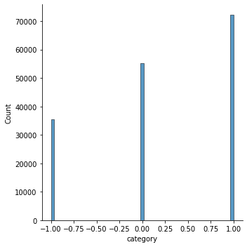

```python
sns.displot(df_t['category'])
```

### Through the graph below, we can see that there is no significant difference between the average amount of characters used for positive and negative texts. However, it was possible to notice that the neutral texts on average contain a much smaller amount of characters compared to the other categories.

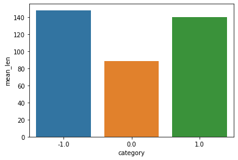

```python
def mean_size(df):
    mean = []
    category = df['category'].unique()
    for c in category:
        d = df.loc[df['category'] == c]
        m = d['len_text'].mean()
        mean.append(m)

    mean_df = pd.DataFrame({'category': category, 'mean_len': mean})
    sns.barplot(x='category', y='mean_len', data= mean_df)

df_t['len_text'] = df_t['text'].str.len()
mean_size(df_t)
```

# Reddit

```python
df_r = pd.read_csv('Reddit_Data.csv')
df_r.head()
```

|  | clean_comment | category |
| --- | --- | --- |
| 0 | family mormon have never tried explain them t... | 1 |
| 1 | buddhism has very much lot compatible with chr... | 1 |
| 2 | seriously don say thing first all they won get... | -1 |
| 3 | what you have learned yours and only yours wha... | 0 |
| 4 | for your own benefit you may want read living ... | 1 |

```python
print("Records with null values")
df_r.isnull().sum()
```

```
Records with null values
```

```
clean_comment    100
category           0
dtype: int64
```

```python
# Rename attribute clean_text
df_r.rename(columns ={'clean_comment': 'text'}, inplace = True)
# Drop null records
df_r.dropna(inplace=True)
```

### As mentioned before, the database is unbalanced with the smallest number of records in the negative category.

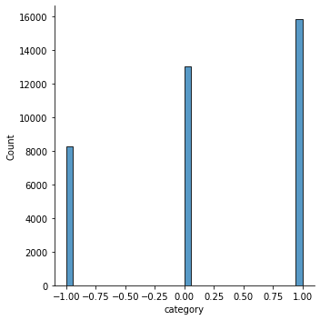

```python
sns.displot(df_r['category'])
```

### Through the graph below, we can see that there is slice difference between the average amount of characters used for positive and negative texts. However, it was possible to notice that the neutral texts on average, contain a much smaller amount of characters compared to the other categories.

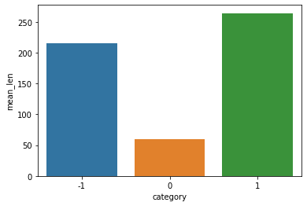

```python
df_r['len_text'] = df_r['text'].str.len()
mean_size(df_r)
```

# Text cleaning

### Our data cleaning process consists of 6 steps:

- Remove unicode: Unicode is a globally adopted standard that makes it possible for all characters of all written languages used on the planet to be represented on computers. However, in this set of characters there are symbols, accents, among others that would make our model less efficient.
- Only alphabets: As we are only concerned with classifying texts. Numerical characters and punctuation we consider as noise and would make our model less efficient. Therefore, we want to extract only the alphabetic characters from the texts.
- Lower case or upper case: All text must be capitalized or all text lowercase. Because computers understand that words like **Buy** and **buy** are distinct, which would cause noise in our model.
- Tokenization: it's the process of segmenting running text into phrases and words. In this case we will use word tokenization. This process is crucial for the next steps.
- Stopwords: stopwords are words like he, she, one, one, among others that can be considered irrelevant in natural language processing in most cases. If we create a Bag-of-words, for example, the highest frequency of words will be stopwords. Therefore, these words should be removed would reduce the noise of the analyzed data.
- Normalization/Lemmatization: It aims to reduce a word to its base form and group different forms of the same word by removing the suffix and prefix from each word. Lemmatization resolves words into their dictionary form (known as a lemma), for which it requires detailed dictionaries in which the algorithm can look up and link words to the corresponding lemmas. For example, the words "running" and "ran" are all forms of the same word run. However, lemmatization without considering the part of speech (**POS**) can lead to some errors, for example, **lemmatize("running") results in running, but lemmatize("running", pos='v') result in run**.

To know more about, acess [POS](https://towardsdatascience.com/part-of-speech-tagging-for-beginners-3a0754b2ebba)

```python
lm = WordNetLemmatizer()

def get_wordnet_pos(treebank_tag):

    if treebank_tag.startswith('J'):
        return wordnet.ADJ
    elif treebank_tag.startswith('V'):
        return wordnet.VERB
    elif treebank_tag.startswith('R'):
        return wordnet.ADV
    else:
        return wordnet.NOUN

def text_clean(text):

    #Remove Unicode characters
    text = re.sub(r'[^\x00-\x7F]+', '', text)

    #Filter to allow only alphabets
    text = re.sub(r'[^a-zA-Z\']', ' ', text)

    #Converting Text to Lowercase
    text = text.lower()

    #tokenization
    text_tokenized = word_tokenize(text)

    #Lemmatization
    lemm = []
    tag = pos_tag(text_tokenized)
    stop_words = stopwords.words('english')
    for word, pos in tag:
        if word not in stop_words:
            wordnet_pos = get_wordnet_pos(pos)
            lemm.append(lm.lemmatize(word, pos=wordnet_pos))

    new_text = ' '.join(str(word) for word in lemm)


    return new_text
```

### Clean Twitter and Reddit texts

```python
#Tweeter
df_t['text_clean'] = df_t['text'].apply(text_clean)
df_t.head()
```

|  | text | category | len_text | text_clean |
| --- | --- | --- | --- | --- |
| 0 | when modi promised “minimum government maximum... | -1.0 | 210 | modi promise minimum government maximum govern... |
| 1 | talk all the nonsense and continue all the dra... | 0.0 | 68 | talk nonsense continue drama vote modi |
| 2 | what did just say vote for modi welcome bjp t... | 1.0 | 117 | say vote modi welcome bjp tell rahul main camp... |
| 3 | asking his supporters prefix chowkidar their n... | 1.0 | 212 | ask supporter prefix chowkidar name modi great... |
| 4 | answer who among these the most powerful world... | 1.0 | 81 | answer among powerful world leader today trump... |

```python
#Reddit
df_r['text_clean'] = df_r['text'].apply(text_clean)
df_r.head()
```

|  | text | category | len_text | text_clean |
| --- | --- | --- | --- | --- |
| 0 | family mormon have never tried explain them t... | 1 | 261 | family mormon never try explain still stare pu... |
| 1 | buddhism has very much lot compatible with chr... | 1 | 1269 | buddhism much lot compatible christianity espe... |
| 2 | seriously don say thing first all they won get... | -1 | 460 | seriously say thing first get complex explain ... |
| 3 | what you have learned yours and only yours wha... | 0 | 168 | learn want teach different focus goal wrap pap... |
| 4 | for your own benefit you may want read living ... | 1 | 691 | benefit may want read live buddha live christ ... |

### After cleaning the data, how about presenting the most spoken words on twitter. We will use wordcloud for this.

```python
def most_words(corpus):
    word_cloud = ""
    for row in corpus:
        for word in row:
            word_cloud+=" ".join(word)

    wordcloud = WordCloud(width = 1000, height = 1000,
                          background_color ='white',min_font_size = 10).generate(word_cloud)

    plt.figure(figsize=(15,10))
    plt.imshow(wordcloud, interpolation='bilinear')
```

### Twitter

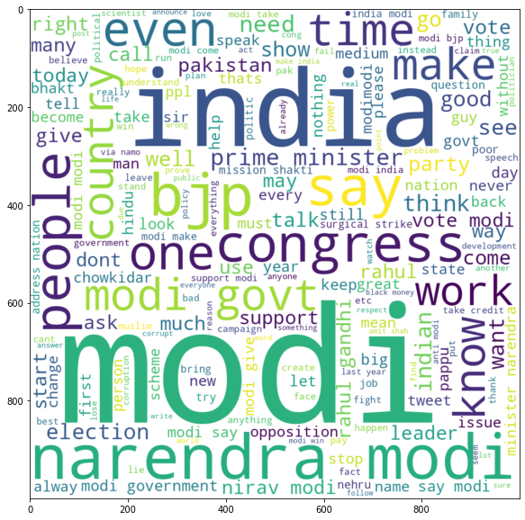

```python
corpus = df_t.text_clean.copy()
most_words(corpus)
```

### Reddit

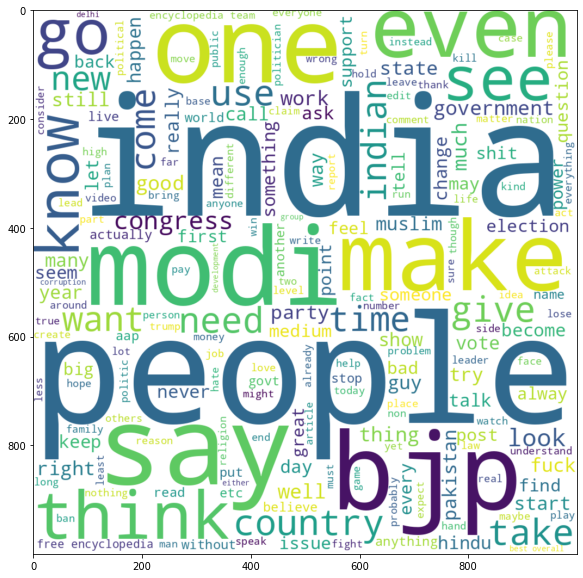

```python
corpus = df_r.text_clean.copy()
most_words(corpus)
```

# Model

### After pre-processing the data, it's time to create our models. First let's select Twitter data for training, and Reddit data for testing.

```python
## get target
y_train = df_t["category"].values
y_test = df_r["category"].values
```

### Text to numeric database

We know that machine learning algorithms only understand numbers, so the following question arises: how will we use texts for this task? There are several methodologies for transforming textual data into number data, and one of the most famous is called bag-of-words. Bag-of-word is characterized as a type of vector model that assigns weights to terms, corresponding to the number of observed occurrences of the terms in the text, that is, the frequency. Then, all words become characteristics, and the value contained represents the frequency of the word in that sentence. See example below.

|  | I | like | dogs | cats | and |
| --- | --- | --- | --- | --- | --- |
| I like dogs | 1 | 1 | 1 | 0 | 0 |
| I like cats | 1 | 1 | 0 | 1 | 0 |
| I like dogs and I like cats | 1 | 2 | 1 | 1 | 1 |

An adaptation of Bag-of_word is the Term Frequency – Inverse Document Frequency (TF-IDF). This algorithm uses the same concept of frequency of terms, but it works with an adaptation to improve its performance. In this algorithm, the words that appear the most in the set of all texts (corpus) receive a lower weight in relation to the other words. This is easily explained, as the more the word is repeated in the corpus, the less important it is for the meaning of the sentence.

Another important concept to mention is N-gram. N-gram is the probability that N words are together. Example, given the sentence I like dogs, with 2-gram would result in {I like, like dogs}, this is used because often a single word doesn't have much meaning, but a conjunction of words can give more meaning to the text. The choice of N-gram is generally according to its computational capacity, as the higher the N, the more combinations it will have, which results in greater dimensionality. In this notebook, we will use **TF-IDF** and **N-gram** to generate our word dictionary. For computational reasons, we will limit our dictionary to **10000** possibilities, as can be seen below.

```python
## Tf-Idf (advanced variant of BoW with 2-gram - Twitter database
corpus = df_t["text_clean"]
vectorizer = feature_extraction.text.TfidfVectorizer(max_features=10000, ngram_range=(1,2))
vectorizer.fit(corpus)
X_train = vectorizer.transform(corpus)
```

### Features selection

```python
y = df_t["category"]
categories = y.unique()
X_features = vectorizer.get_feature_names()
p_value_limit = 0.95
df_features = pd.DataFrame()

for cat in categories:
    chi2, p = feature_selection.chi2(X_train, y == cat)
    df_features = df_features.append(pd.DataFrame({"feature": X_features, "score": 1-p, "y": cat}))
    df_features = df_features.sort_values(["y","score"], ascending= [True,False])
    df_features = df_features[df_features["score"] > p_value_limit]

X_features = df_features["feature"].unique().tolist()
```

```python
for cat in categories:
    if cat == -1.0:
        category = 'Negative'
    elif cat == 0.0:
        category = 'Neutral'
    else:
        category = 'Positive'

    print("# {}:".format(category))
    print("  . selected features:",
    len(df_features[df_features["y"]==cat]))
    print("  . top features:", ",".join(
    df_features[df_features["y"]==cat]["feature"].values[:10]))
    print(" ")
```

```
# Negative:
  . selected features: 1591
  . top features: afraid,anger,angry,bad,badly,behind,best,black,black money,blind

# Neutral:
  . selected features: 2527
  . top features: able,action,bad,behind,best,black,black money,clean,clear,common

# Positive:
  . selected features: 1901
  . top features: able,action,awesome,bad,beloved,best,brave,brilliant,capable,chit
```

### From the moment we have a new dictionary, we have to carry out the vectorization process again for the Twitter and Reddit database.

```python
corpus = df_t['text_clean']
vectorizer = feature_extraction.text.TfidfVectorizer(vocabulary=X_features)
vectorizer.fit(corpus)
X_train = vectorizer.transform(corpus)
```

```python
corpus = df_r['text_clean']
vectorizer.fit(corpus)
X_test = vectorizer.transform(corpus)
```

# Model evaluate

In this part we will test two distinct algorithms, Naive Bayes and Random Forest. Naive Bayes is a probabilistic algorithm based on the Bayes theorem. On the other hand, radom forest is an algorithm based on decision trees, where each forest tree votes on the classification that belongs to the sentence, and the one with the highest number of votes is the final classification.

```python
def get_results(y_test, predicted, predicted_prob):
    accuracy = metrics.accuracy_score(y_test, predicted)
    auc = metrics.roc_auc_score(y_test, predicted_prob, multi_class="ovr")
    print("Accuracy:",  round(accuracy,2))
    print("Auc:", round(auc,2))
    print("Detail:")
    print(metrics.classification_report(y_test, predicted))

def plot_confusion_m(clf, X_test, y_test):
    plot_confusion_matrix(clf, X_test, y_test)
    plt.show()

def plot_roc_curv(y_test, predicted_prob):
    fig, ax = plt.subplots(nrows=1, ncols=2)
    categories = np.unique(y_test)
    y_test_array = pd.get_dummies(y_test, drop_first=False).values

    ## Plot roc
    for i in range(len(categories)):
        fpr, tpr, thresholds = metrics.roc_curve(y_test_array[:,i], predicted_prob[:,i])
        ax[0].plot(fpr, tpr, lw=3, label='{0} (area={1:0.2f})'.format(categories[i], metrics.auc(fpr, tpr)))

    ax[0].plot([0,1], [0,1], color='navy', lw=3, linestyle='--')
    ax[0].set(xlim=[-0.05,1.0], ylim=[0.0,1.05],
          xlabel='False Positive Rate',
          ylabel="Recall",
          title="ROC curve")

    ax[0].legend(loc="lower right")
    ax[0].grid(True)

    ## Plot precision-recall curve
    for i in range(len(categories)):
        precision, recall, thresholds = metrics.precision_recall_curve(y_test_array[:,i], predicted_prob[:,i])
        ax[1].plot(recall, precision, lw=3,
                   label='{0} (area={1:0.2f})'.format(categories[i], metrics.auc(recall, precision)))

    ax[1].set(xlim=[0.0,1.05], ylim=[0.0,1.05], xlabel='Recall', ylabel="Precision", title="Precision-Recall curve")
    ax[1].legend(loc="best")
    ax[1].grid(True)
    plt.show()
```

### Naive Bayes

```python
clf_nb = MultinomialNB()

clf_nb.fit(X_train, y_train)
predicted = clf_nb.predict(X_test)
predicted_prob = clf_nb.predict_proba(X_test)
```

```
Accuracy: 0.63
Auc: 0.92
Detail:
              precision    recall  f1-score   support

          -1       0.84      0.55      0.66      8277
           0       0.82      0.30      0.43     13042
           1       0.55      0.94      0.69     15830

    accuracy                           0.63     37149
   macro avg       0.74      0.59      0.60     37149
weighted avg       0.71      0.63      0.60     37149
```

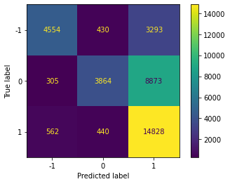

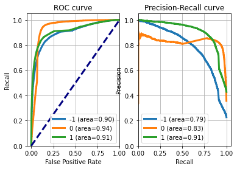

```python
get_results(y_test, predicted, predicted_prob)
plot_confusion_m(clf_nb, X_test, y_test)
plot_roc_curv(y_test, predicted_prob)
```

### Random Forest

```python
clf_rf = RandomForestClassifier()

clf_rf.fit(X_train, y_train)
predicted = clf_rf.predict(X_test)
predicted_prob = clf_rf.predict_proba(X_test)
```

```
Accuracy: 0.81
Auc: 0.92
Detail:
              precision    recall  f1-score   support

          -1       0.82      0.54      0.65      8277
           0       0.80      0.94      0.86     13042
           1       0.82      0.85      0.83     15830

    accuracy                           0.81     37149
   macro avg       0.81      0.77      0.78     37149
weighted avg       0.81      0.81      0.80     37149
```

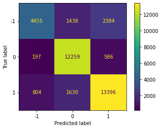

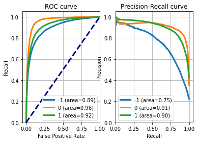

```python
get_results(y_test, predicted, predicted_prob)
plot_confusion_m(clf_rf, X_test, y_test)
plot_roc_curv(y_test, predicted_prob)
```

# Conclusions

Although the Random Forest classifier performed better overall than the Naive Bayes, both algorithms had low results when trying to classify the sentences from the negative class. This may have occurred due to the amount of predominant characteristics of the negative class that are present in the other classes. For example, for the negative class we selected **1591** words, of which **660** are also in the positive class, ie **41%**. In relation to the neutral class, we have a total of **1074** belonging to both groups, that is, **67%**. The results are presented below.

```python
negative =  df_features['feature'].loc[df_features['y']==-1].to_list()
neutral =  df_features['feature'].loc[df_features['y']==0].to_list()
positive =  df_features['feature'].loc[df_features['y']==1].to_list()
```

### Intersection of features of the negative and positive class.

```python
inter_np = np.intersect1d(negative, positive)
print(len(inter_np))
```

```
660
```

### Intersection of features of the negative and neutral class.

```python
inter_nn = np.intersect1d(negative, neutral)
print(len(inter_nn))
```

```
1074
```

### Intersection of features to three class.

```python
inter = np.intersect1d(inter_np, inter_nn)
print(len(inter))
```

```
536
```